# Machine Learning with Coursera

Jae Kwan Koo

## Classification

### tutorial

예측변수 y가 discrete value인 경우인 분류(classification)문제에 대해 알아보자.  
분류알고리즘 중 하나인 `Logistic Regression(로지스틱 회귀)`에 대해 알아볼 것이다.

- What is the Classification?
  - 스팸 이메일 분류
  - 특정 거래의 사기유무
  - 특정 사람이 도용된 신용카드 or 비밀번호 사용여부
  - 악성, 양성 종양 구분

| type | description |
| --- | --- |
| 0 | negative class |
| 1 | positive class |

우선 우리는 0과 1인 경우만 분류하는 classification문제를 생각하자.  
(차후, 다중분류(multiclass classification)을 다뤄보도록 한다.)

### Why do we use the Logistic Regression?

분류문제에 대해 배웠던 선형회귀 알고리즘을 데이터에 대해 적용해보자  
직선을 그어 생각해봤을 때, 0.5를 임계값으로 두어 확률이 0.5보다크면 1로 생각하고 작으면 0으로 생각하게 된다.

선형회귀식이 분류문제를 해결하는데 잘 작동하는 것 처럼 보이지만, 오른쪽 끝에 새로운 관측치가 있다고 가정했을 때, 회귀식은 오른편으로 약간 이끌리게 된다. 이 과정 이후 다시 tumor size에 대해 잘 작동하는지 생각하면 이전과는 결과가 약간 달라짐을 알 수 있다. 한 관측치를 추가했을 뿐인데 이 관측치는 우리에게 새로운 정보를 주지 못한다.

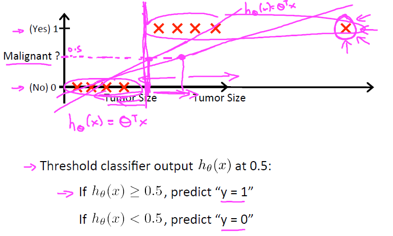

ISLR에서는 카드대금과 연체확률에 대한 예시를 보여준다.  
카드대금이 0에 가까우면 연체 예측확률이 음수가 되고, 카드대금이 아주 큰 경우에는 예측확률이 1보다 크게 되는데, 카드대금이 얼마든 상관없이 연체확률은 0과 1사이에 있어야 되기 때문에 이 예측은 맞지가 않다.  
(만약 X의 범위가 제한되어 있지 않다면, 매우 큰 X에 대해서는 확률값이 1을 넘겨버리는 경우가 존재하게 된다.)

이 문제를 해결하기 위해서는 모든 X값에 대해 0과 1사이의 값을 제공하는 함수를 사용하여 f(X)를 모델링 해야한다.

많은 함수가 이 조건을 만족하지만, 로지스틱 회귀에서는 로지스틱 함수(logistic function, sigmoid function)를 사용한다.

통계 관점에서 로지스틱 회귀모형을 이해 해보자.

### logistic regression model

$h(x) = \beta_0+\beta_1X_i$ 와 같이 선형모형으로 두게 되면, 경우에 따라 h(x)>1, h(x)<0이 될 수 있다고 했다.

그렇다면 항상 어떤 input X에 대해서 0과 1사이의 값을 둘 수 있는 중간에서 걸어줄 수 있는 연계함수가 필요하다.  
가장 간편한 경우는 이 연계함수 g를 누적분포함수의 역함수로 두면 된다. 확률을 누적한 그래프는 시작하지 않았다면 0일 것이고, 모든 경우가 다 나와서 모든 확률을 누적했다면 결국 1이된다. 이 함수의 역함수는 0에서 1까지 가질 것이다.

$$g(h_\theta(x)) = x^t\theta$$
위의 반응변수에 걸리는 연계함수가 만약 항등함수이면 선형회귀와 같다. 실제로 선형회귀는 연계함수가 항등함수인 경우이다.

이제 이 연계함수를 누적분포함수의 역함수로 걸어보자. 왜냐하면 반응변수의 값은 0~1만 가져야 하므로 반응변수의 범위는 누적분포함수와 같다. $h(x) = \int_{-\infty}^xf(x)dx$로 생각하면, 연계함수 g는 이것의 역함수가 되어야 우변처럼 $x^t\beta$로 나올 것이다.

$$h_\theta(x) = g^{-1}(x^t\theta) = \int_{-\infty}^\eta f(x)dx$$

`로지스틱 분포`를 f(x)의 확률밀도함수라고 두면

$$f(x) = {e^x\over (1+e^x)^2}$$

위와 같이 얻어진다.

$$h_\theta(x) = g^{-1}(x^t\theta) = \int_{-\infty}^\eta f(x)dx = {e^\eta\over 1+e^\eta}$$

따라서 우리의 가설을 얻었다. 마지막으로 정리하기 위해 $\eta=x^t\theta$를 대입하면

$$e^{x^t\theta}\over 1+e^{x^t\theta}$$

이 최종 식이다.

$$log({h_\theta(x)\over1-h_\theta(x)}) = x^t\theta$$

정리하면, 위와 같이 되는데 좌변을 `log-odds` 또는 `logit`이라고 한다.  
연계함수 g가 로짓인 경우를 `로지스틱 회귀모형`이라고 부른다.

$$Logistic function(x) = {e^{x}\over 1+e^{x}} = {1\over1+e^{-x}} = {1\over2} + {1\over2}tanh({x\over2})$$

로지스틱 회귀는 **분류**알고리즘으로 사용하지만, **회귀**라는 단어 때문에 헛갈리지 않기를 바란다. 이 이름은 Linear Regression과 같은 technique을 사용했기 때문에 붙여진 이름이라고 한다.

[What is the logistic regression?](https://towardsdatascience.com/understanding-logistic-regression-9b02c2aec102)

## Hypothesis Representation

이제 위에서 봤던 로지스틱 함수를 이용해 로지스틱 회귀모형을 표현해보자.

$$h_\theta{(x)} = g(\theta^Tx) = {1\over 1+e^{-\theta^Tx}}$$

여기서 g(z)는 $1\over1+e^{-z}$인 `logistric function`을 의미한다.  
g(z)는 0과 1사이의 s자형 개형을 가지며, x=0일 때, 0.5를 지나는 함수이다.  
이 로지스틱 함수를 이용하여 우리가 원하는 가설의 범위가 0과 1사이가 되도록 하는 것이다.

아래는 가설을 어떤식으로 해석을 할 것인지를 보여준다.

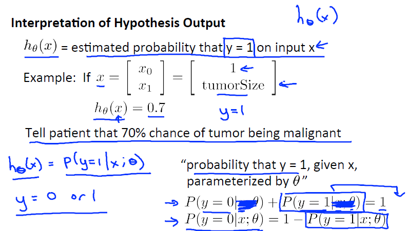

어떤 input x들에 대해 y가 1인 추정된 확률이라고 하자.

x0 : 선형회귀부터 계속 1이라고 취급하고 있다.  
x1 : 종양의 크기(tumorsize)

특정 크기 종양의 환자에 대한 정보를 x벡터에 넣었더니 0.7이 나왔다.  
-> 이 환자에 대해서 y = 1일 확률은 0.7(악성종양일 확률이 0.7)

y값은 0 or 1이기 때문에 이 경우, 0일 확률은 1 - 0.7 = 0.3이 된다.

## Decision boundary

그렇다면 어떤 결정 경계(decision boundary)를 가지고 분류를 하게 되는걸까?

y=1 : $h_\theta(x)\ge0.5$

y=0 : $h_\theta(x)<0.5$

가설의 범위는 0과 1사이이다. probability가 0.5이상이면 1로 간주하겠다는 것이다.  
이 말은 즉, $\theta^TX>0$과 같은 말이다. 그래프 개형을 보면 0.5이상을 가지는 y범위에 대해 x의 범위는 0이상임을 알 수 있다.

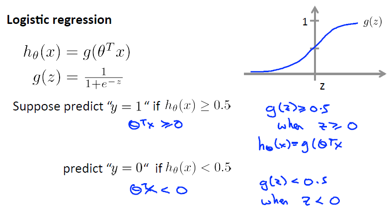

### Linear decision boundary

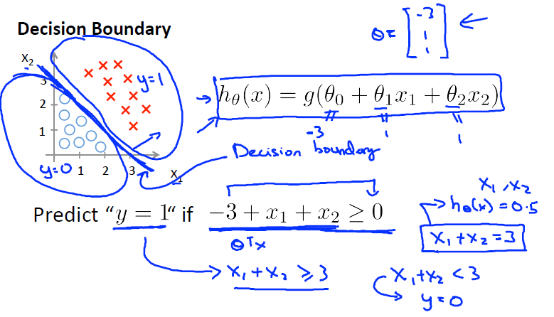

예컨대, $\theta = [-3, 1, 1]^T$인 경우를 생각하자.  
$\theta^TX>0$이므로 $x_1+x_2\ge3$일 때, y=1로 예측한다.

### Non-linear decision boundary

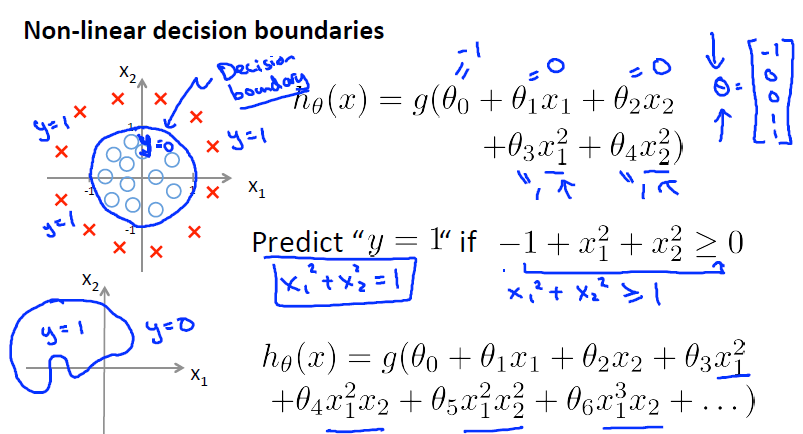

이전 예제의 가설에 제곱항 2개가 더 추가된 가설이다.  
예컨대, $\theta = [-1, 0, 0, 1, 1]^T$인 경우를 생각하자.  
결과적으로, 중심이 (0,0)이고 반지름이 1인 원의 바깥은 y=1로 예측할 것이다.

또한, 직선으로는 positive, negative를 구분할 수 없는 더 복잡한 decision bondary들이 존재할 수 있다.

## Cost function

**어떻게 $\theta$를 선택할 것인가?**

이전과 마찬가지로 m개의 training set의 observation들이 있고 $\theta_0$부터 $\theta_n$까지 n+1차원이 존재한다.  
물론 $x_0=1$이며, 반응변수 y는 0,1의 값을 가진다.

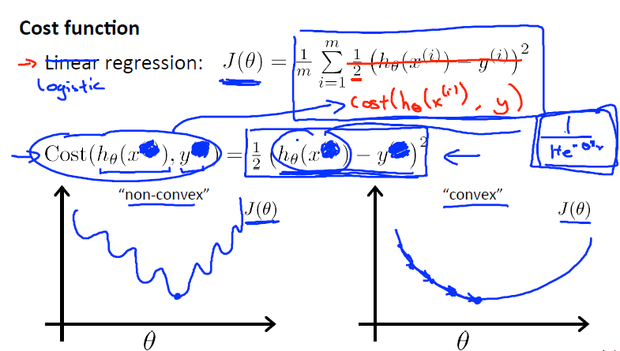

이전의 cost function와 형태는 같다. 하지만, 이번에는 1/m만 summation밖에 꺼냈다.

summation안의 값들을 $cost(h_\theta(x),y)={1\over2}(h_\theta(x)-y)^2$라고 하자.

가설의 형태는 로지스틱 함수의 개형을 가지는 비선형 함수이다. 이런 가설의 형태를 가지는 비용함수 J는 많은 극소점을 가지는 함수가 된다.  
-> 경사하강법을 적용했을 때, 전역 최소값이라는 보장이 없다.

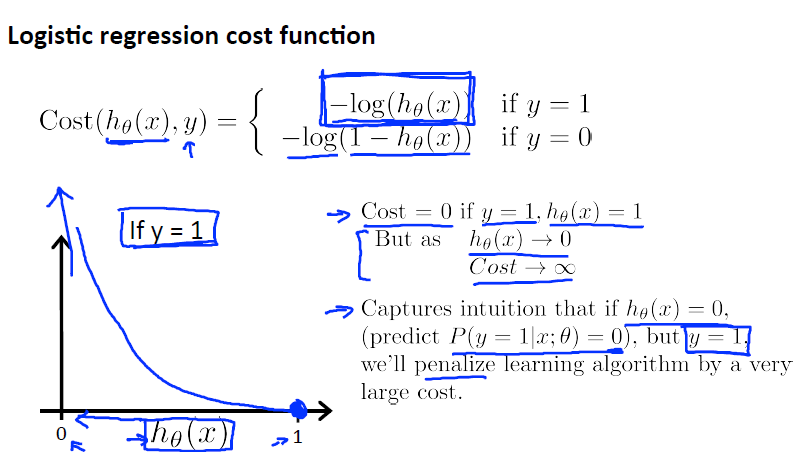

이를 해결하기 위해 새로운 형태의 cost function을 제시하려고 한다.  
아래부터는 얻기까지의 과정이다.

가설의 범위는 0과 1사이기 때문에 -log의 그림을 0과 1사이만 그리면 (1,0)을 찍게 된다.  
y=1일 때를 생각해보면 cost가 0일 때, 당연히 1로 정확히 예측하게 된다.

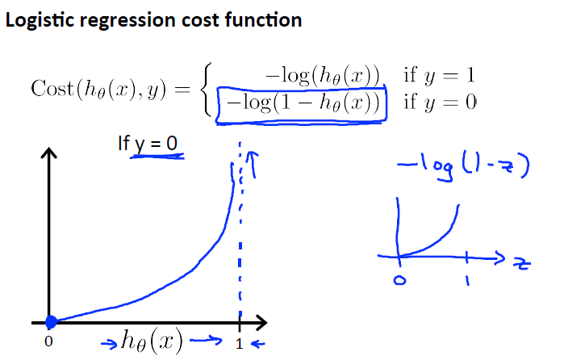

마찬가지이다.

## Simplified cost function and gradient descent

y의 범위에 따라 분리된 함수를 좀 단순화시켜서 확인하고 싶은 생각이 들어졌다.

$$Cost(h_\theta(x),y) = -ylog(h_\theta(x))-(1-y)log(1-h_\theta(x))$$

y가 1과 0을 가지는 것을 이용해서 앞, 뒤를 잘 조절해주면 한 식으로 표현이 가능하다.

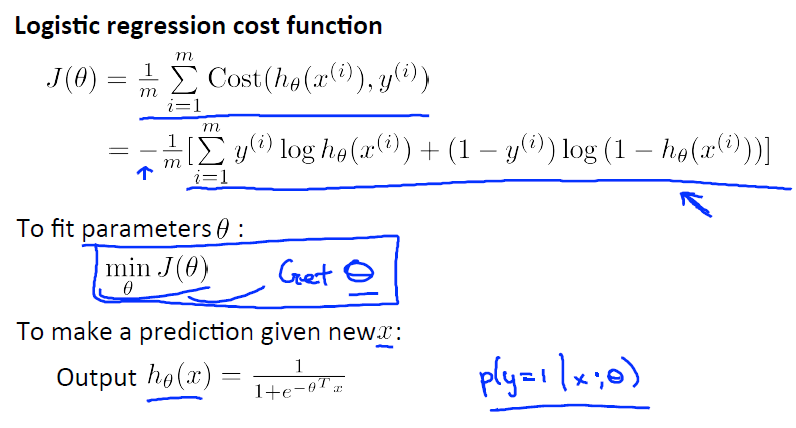

이제 logistic regression의 cost function을 얻었다.  
이 방법으로 표현한 cost function은 logistic regression의 convex를 보장한다.  
이제 global minimum을 찾을 수 있다.

### Why did we choose the cost function like that?

왜 cost function을 저런식으로 결정했는지는 통계적인 이유가 있다.

#### Estimate

추정은 `모수`, 그러니까 알려지지 않았지만 우리가 알고 싶어하는 `unknown parameter`이다. 이 모수와 얼마나 잘 가깝게 추정하는가는 중요한 일 중 하나이다.

training set에서 관측값들이 1부터 m까지 존재한다는 것은 알고있는 사실이다.  
이제 m까지의 값들이 모수적 분포를 가지고 확률표본이라고 가정한다.  
우리가 알고싶은 모수 $\theta$는 가능도함수가 최대가 되는 값이다. 여기서 $\theta$를 최대가능도추정량(MLE)라고 한다.

$$L(\theta;x_1,...,x_m) = f(x_1;\theta)\times...\times f(x_m;\theta)$$

가능도함수가 있으면, 나올 확률이 높은 $\theta$가 좋을 것이다.  
그래서 가능도함수가 최대가 되는 지점의 $\theta$를 구하고 싶은 것이다.  
계산의 편의를 위해 likelihood function에 log를 씌워 계산하게 되는데, log를 씌운다고 최대 최소의 지점은 변하지 않기 때문이다.

#### Likelihood function of Logistic regreession

로지스틱 모형에서 y는 0과 1만을 가지는 반응변수이므로 y를 2가지의 결과 값만 가지는 베르누이 확률변수라고 보자.

$$p(y|x,h) = Ber(y|h(x))$$

$$logL(h) = log \prod_{i=1}^mh_i(x_i)^{y_i}(1-h_i(x_i))^{(1-y_i)} = \sum_{i=1}^m(y_ilogh_i(x_i)) + (1-y_i)log(1-h_i(x_i))$$

계산의 편의를 위해 likelihood function에 log를 씌운 log likelihood function을 이용했다.  
h(x)는 로지스틱 함수이므로 대입한 결과는 아래와 같다.

$$logL(h) = \sum(y_ilog({1\over1+exp(-\theta^Tx_i)})
-(l-y_i)log({exp(-\theta^Tx_i)\over1+exp(-\theta^Tx_i)}))$$

이 값은 $\theta$에 대한 비선형 함수이므로 선형 모형과 같이 간단하게 gradient가 0이 되는 모수 $\theta$값에 대한 수식을 구할 수 없다.  
수치적인 최적화 방법(numerical optimization)을 통해 최적 모수의 값을 구해야 한다.  
여기서 최적화 방법은 gradient descent과 같은 방법이 되겠다.

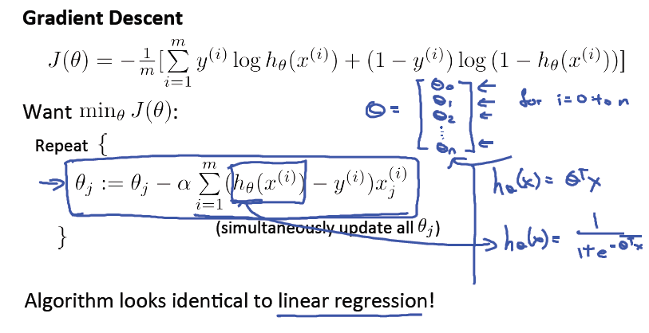

업데이트 규칙이 선형회귀와 같다는 것을 알 수 있다.

- vectorized implementation

n+1개의 $\theta$들을 한번에 업데이트 시킨다.  
$\theta:=theta-{\alpha\over m}X^T(g(X\theta)-\vec{y})$

- feature scaling

매우 다른 범위를 가지는 feature들에 대해 feature scaling을 적용하여 gradient descent를 빠르게 수렴하게 만들 수 있다.

## Advanced optimization

Cost function $J(\theta)$를 최소화가 목적이다.

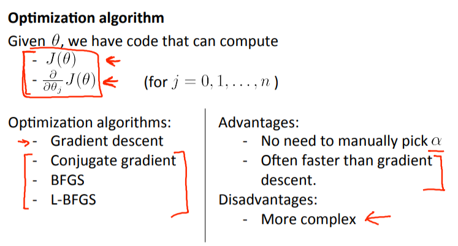

advanced optimization algorithms과 몇몇 개념들은 gradient descent보다 훨씬 더 빨리 진행할 수 있고, 매우 큰 ML학습 문제(feature가 너무 많은 경우 등등..)로 더 잘 확장될 수 있다.

gradient descent를 제외한 3가지는 더 정교한 방법으로 cost function을 최소화시키고 계산한다.

## Multi-class classification : one-vs-all

다중분류에 대해서는 로지스틱 회귀를 어떻게 적용할까?

- Example
  - Email foldering/tagging : work, friends, family, hobby
  - medical diagrams : Not ill, Cold, Flu
  - Weather : Sunny, Cloudy, Rain, Snow

y의 index를 결정할 때, 0부터 시작하느냐 1부터 시작하느냐는 중요하지 않다.  
단지 class를 구분하는 바구니의 이름일 뿐이다.

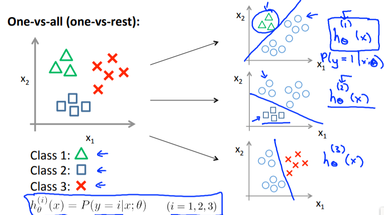

만약 클래스 1을 구하고 싶으면 클래스1을 제외한 나머지 모두를 0이라고 간주한 채로 이진분류를 진행한다. 나머지에 대해서도 마찬가지로 진행한다.

3개의 로지스틱 회귀를 통해 각 클래스i에 대해 y=i일 확률을 예측했다.  
이제 새로운 input x가 들어온다면 3가지의 가설에 모두 넣어 가장 높은 확률을 보이는 곳으로 분류하면 된다.

## Exercise

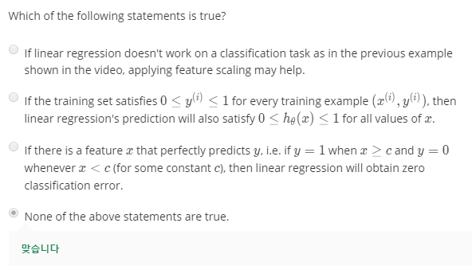

피쳐들의 범위가 매우 차이날 때, 수렴속도를 올리기 위해 진행하는 스케일링이 선형회귀가 분류를 잘하게 도와주지 않는다.  
작은 범위에서 fitted된 모형이 있다고 하자. 분명 training set의 y범위는 0과1사이에 들어올 만큼 작다. 하지만 fitted model은 쭉 뻗은 직선으로 경향을 표현하게 되는데 큰, 작은 새로운 input x를 넣으면 함수 값은 0보다 작을수도, 1보다 클수도 있는 것은 당연하다.  
비록 모든 training set들이 y값을 0과 1만 가진다고 할지라도 선형회귀는 $h_\theta(x)$가 1보다 클수도 있고, 0보다 작을수도 있다.

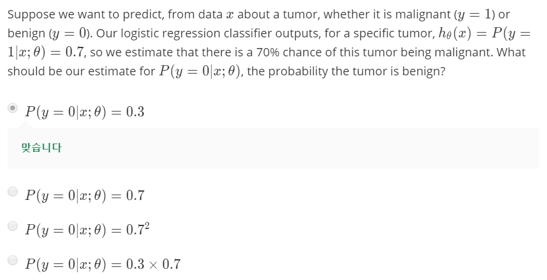

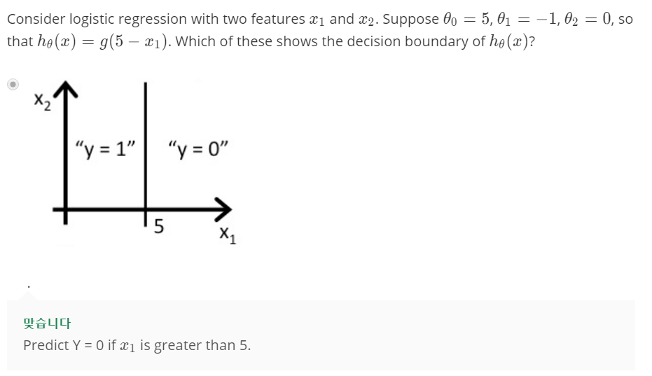

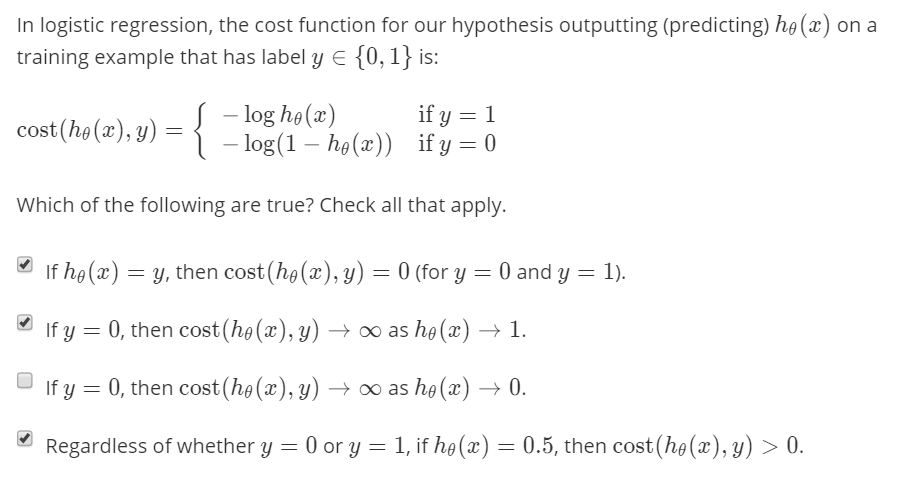

h대신 y를 대입하고 생각해보자. log1은 0이다.  
-log0은 inf  
if y=0, cost->0 as h->0  
-log(0.5)>0

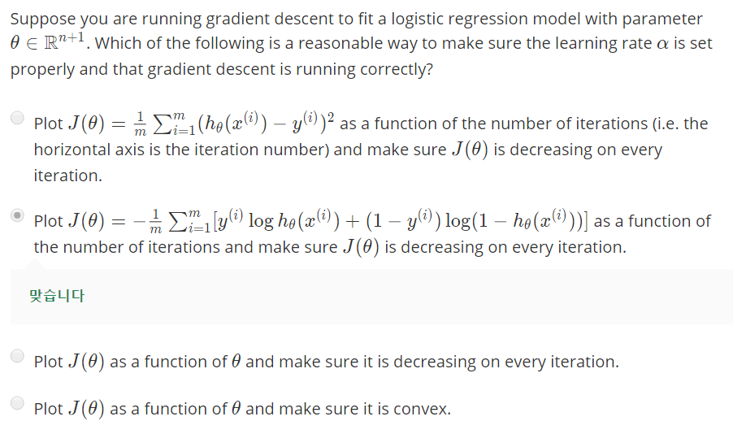

learning rate를 선택하는 가장 합리적인 방법은 비용함수에 대해 plot을 그려 확인하는 것이다.

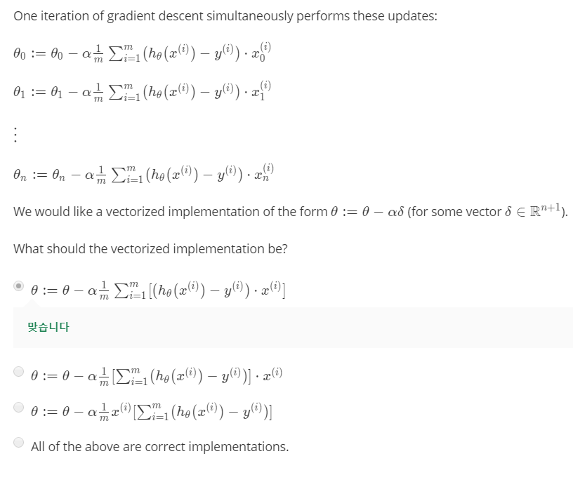

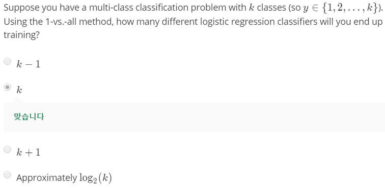

2개만 있을경우 1개의 classifier만 있어도 2개가 구분이 된다. 모아니면 도 이기 때문이다.

3개 이상일 경우, a,b,c가 있다고 하자.  
a를 1로 보고 b,c를 0으로 본 뒤, a를 분류한다.  
b를 1로 보고 a,c를 0으로 본 뒤, b를 분류한다.  
이렇게 2번 진행해도 c를 구분하지 못했다. 하나씩 분류하다보니 나머지 2종류는 필연적으로 섞여있기 때문이다.

## Test

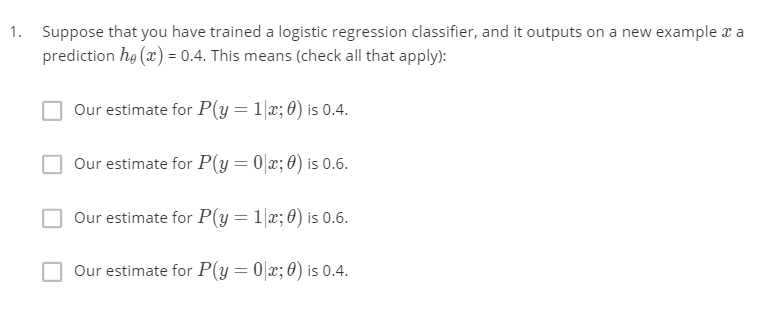

y=1일 확률이 0.4라고 예측했다. y=0일 확률은 0.6이다.

1,2

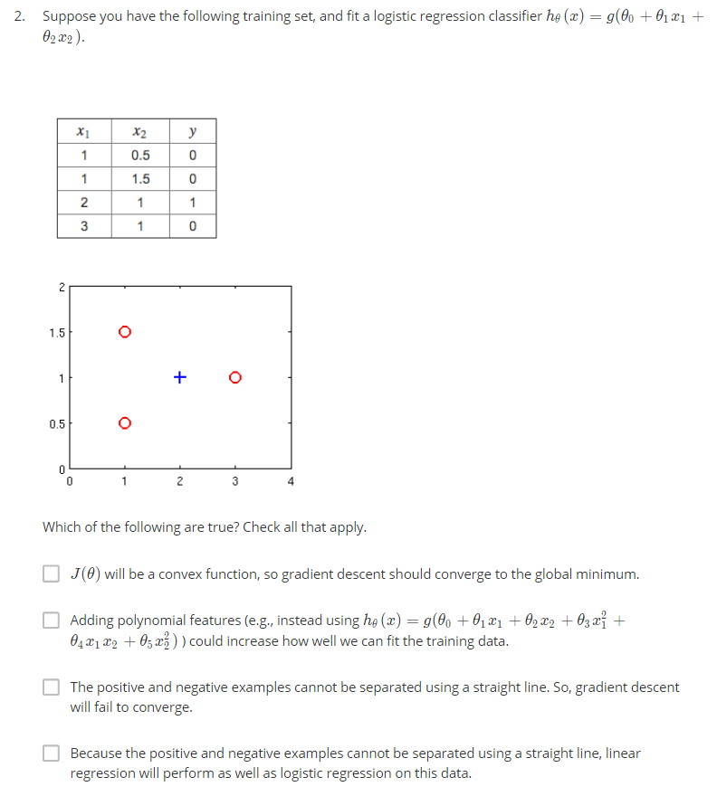

logistic regression의 비용함수는 convex가 되게 했었다. 따라서 global minimum을 가진다.  
더 고차원의 항들을 추가함으로 더 smooth한 그래프를 만들 수 있다.  
잘 분리하지는 못하겠지만, 수렴에 실패하지는 않을 것이다.  
뭔 소리인지 모르겠다.

1,2

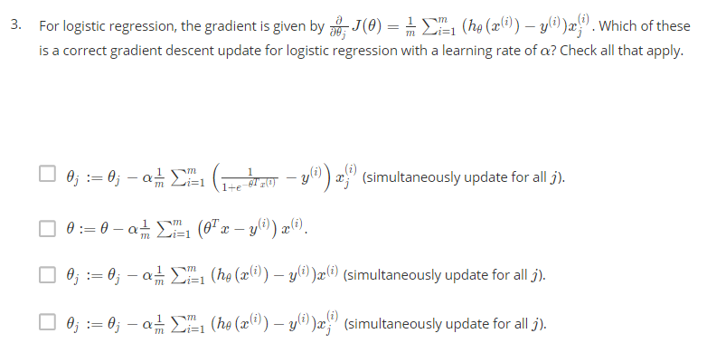

동시에 업데이트가 되어야 한다.  
첨자도 잘 눈여겨 봐야 한다.

1,4

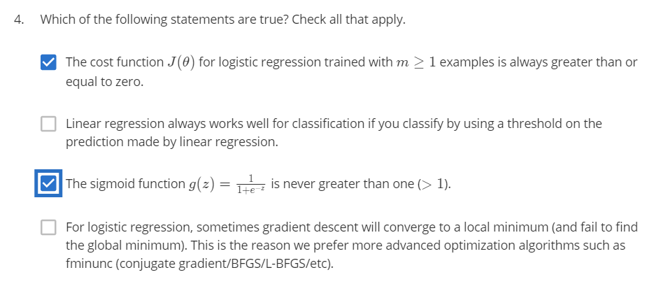

비용함수 j는 항상 0보다 크거나 같다. <- 식을 잘 살펴보자.  
선형회귀는 분류에 대해 잘 수행하지 못한다.  
시그모이드 함수는 0과 1사이의 y범위를 가진다.  
수렴실패에 대한 대안이 아니라 단지 장단점에 대한 이야기가 있었다.

1,3

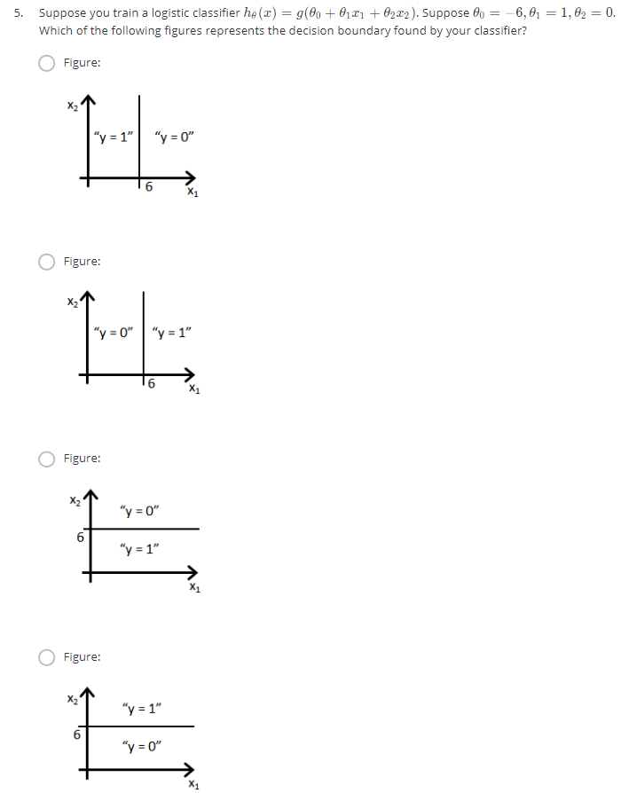

함수 g안의 값이 0이상인 범위가 y=1이라고 예측

2

## Practice

### Library

```r
library(data.table)
library(tidyverse)

library(caret)

library(ggthemes)
library(gganimate)
library(plotly)
```

### data1

```r
data1 <- fread("ex2data1.txt", col.names = c("x1", "x2", "y"))

str(data1)
```

```
## Classes 'data.table' and 'data.frame':   100 obs. of  3 variables:
##  $ x1: num  34.6 30.3 35.8 60.2 79 ...
##  $ x2: num  78 43.9 72.9 86.3 75.3 ...
##  $ y : int  0 0 0 1 1 0 1 1 1 1 ...
##  - attr(*, ".internal.selfref")=<externalptr>
```

### Scatter plot

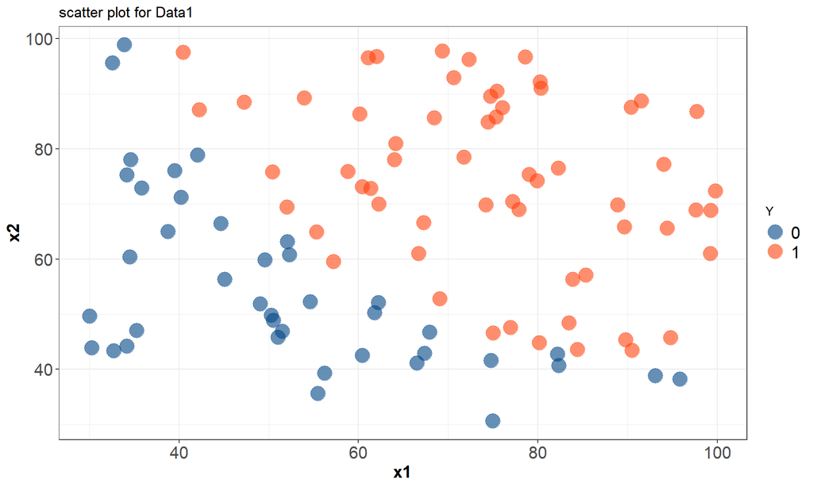

```r
ggplot(data1, aes(x=x1, y=x2, col=as.factor(y))) +
  geom_point(size=6,alpha=0.6)+
  ggtitle("scatter plot for Data1")+
  theme_bw() +
  scale_color_calc("Y")+
  theme(axis.text=element_text(size=15),
        axis.title=element_text(size=15,face="bold"),
        legend.text=element_text(size=15))
```

### Density

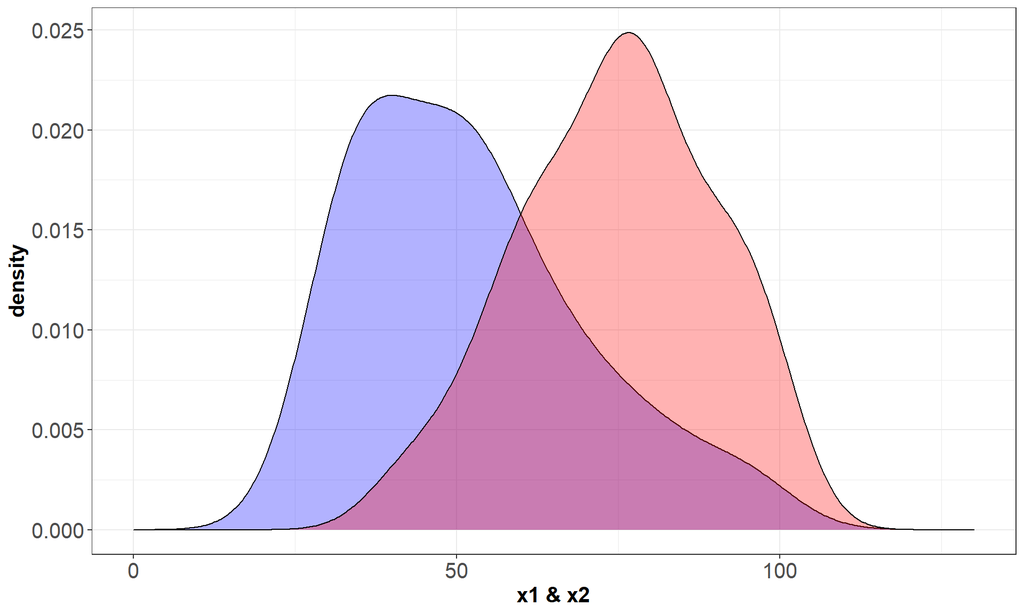

```r
ggplot(data1, aes(x = x1)) +
  geom_density(data=subset(data1, y == '0'), fill = "blue", alpha = 0.3) +
  geom_density(data=subset(data1, y == '1'), fill = "red",  alpha = 0.3) +
  theme_bw() +
  xlim(0,130) +
  theme(axis.text=element_text(size = 15),
        axis.title=element_text(size=15,face="bold")) +
  labs(x = "x1 & x2")
```

### Gradient descent for logistic regression

```r
### sigmoid function

sigmoid <- function(z){
  return(1/(1+exp(-z)))
}

### Cost finction

costfunction <- function(theta){
  g <- sigmoid(X%*%theta)
  m <- nrow(X)

  J <- (1/m)*sum((-Y*log(g))-((1-Y)*log(1-g)))

  return(J)
}



# feature scaling
temp <- scale(data1[,1:2], center = T,scale = T)
data1 <- data.frame(temp, y=data1$y)

# Design Matrix X
temp_x <- as.matrix(data1[, c(1,2)])
X <- cbind(rep(1,nrow(temp_x)), temp_x)

# Response matrix
Y <- as.matrix(data1$y)

# Intial values
theta <- matrix(c(2,2,2), nrow=3)







# learning rate
alpha <- 0.01

cost_history <- NULL
i <- 1

while(T){
  delta <- (t(X) %*% (sigmoid(X%*%theta) - Y)) / length(Y)
  theta <- theta - (alpha*delta)

  cost_history[i] <- costfunction(theta)

  if(i>=2){
    temp[i] <- abs(cost_history[i]-cost_history[i-1])
    if(abs(temp[i])<=10^(-9)) break;
  }

  i <- i+1

  if(i>=100000) break;


}


data.frame("iteration" = i, "cost_on_convergence" = cost_history[i])
```

| iteration | cost_on_convergence |
| --- | --- |
| 56985 | 0.2035063 |

[figure not shown]

```r
temp <- data.frame(iter = 1:i, cost = cost_history[1:i])

theme_set(theme_bw())
p <- ggplot(aes(x = iter,y = cost), data = temp) + geom_line()


p + transition_reveal(iter)
```

```r
# ggplotly(p, height = 350, width=600)
```

### Visualize the Decision boundary

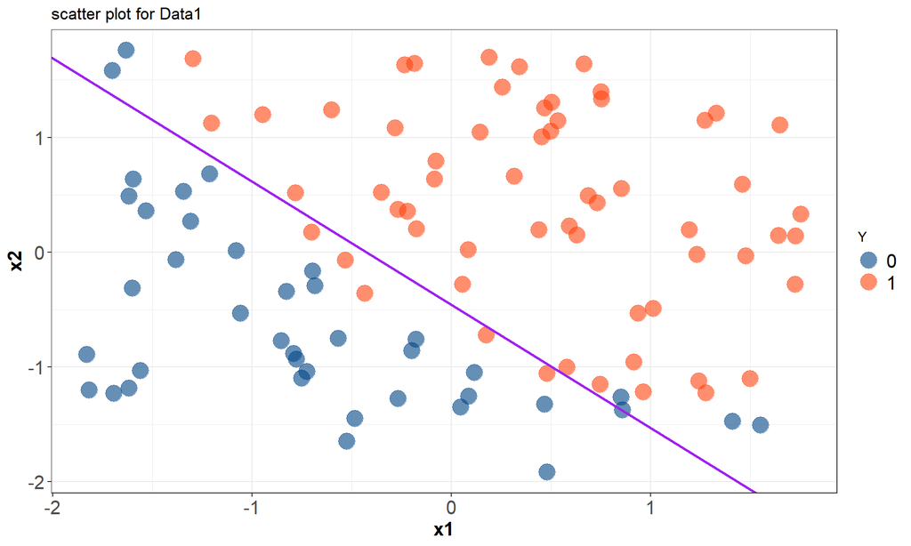

```r
plot_x <- c(min(data1$x1)-2,max(data1$x1)+2)

# Calculate the decision boundary line
plot_y <- (-1/theta[3])*(theta[2]*plot_x+theta[1])

## Calculate slope and intercept
slope =(plot_y[2]-plot_y[1])/(plot_x[2]-plot_x[1])
intercept=plot_y[2]-slope*plot_x[2]

ggplot(data1, aes(x=x1, y=x2, col=as.factor(y))) +
  geom_point(size=6,alpha=0.6)+
  ggtitle("scatter plot for Data1")+
  theme_bw() +
  scale_color_calc("Y")+
  theme(axis.text=element_text(size=15),
        axis.title=element_text(size=15,face="bold"),
        legend.text=element_text(size=15)) +
  geom_abline(intercept = intercept, slope = slope, col="purple", lwd = 1)
```

### Comparison gradient descent with glm()

```r
model <- glm(y~x1+x2,family = 'binomial', data=data1)

temp <- data.frame(rbind(t(theta), model$coefficients))
rownames(temp) <- c("gradient descent", "glm function")
colnames(temp) <- c("intercept", "x1", "x2")

temp
```

|  | intercept | x1 | x2 |
| --- | --- | --- | --- |
| gradient descent | 1.701170 | 3.975799 | 3.708002 |
| glm function | 1.718449 | 4.012903 | 3.743903 |

### Prediction

```r
b0 <- t(theta)[1] # intercept
theta1 <- t(theta)[2] # x1
theta2 <- t(theta)[3] # x2

prob <-
exp(b0 + theta1*data1$x1 + theta2*data1$x2) /
  (1+exp(b0 + theta1*data1$x1 + theta2*data1$x2))

prediction <- ifelse(prob>=0.5, 1, 0)


# table(data1$y, prediction)
confusionMatrix(as.factor(data1$y), as.factor(prediction))
```

```
## Confusion Matrix and Statistics
##
##           Reference
## Prediction  0  1
##          0 34  6
##          1  5 55
##
##                Accuracy : 0.89
##                  95% CI : (0.8117, 0.9438)
##     No Information Rate : 0.61
##     P-Value [Acc > NIR] : 4.336e-10
##
##                   Kappa : 0.7699
##
##  Mcnemar's Test P-Value : 1
##
##             Sensitivity : 0.8718
##             Specificity : 0.9016
##          Pos Pred Value : 0.8500
##          Neg Pred Value : 0.9167
##              Prevalence : 0.3900
##          Detection Rate : 0.3400
##    Detection Prevalence : 0.4000
##       Balanced Accuracy : 0.8867
##
##        'Positive' Class : 0
##
```

gradient descent로 적합한 모형의 confusionmatrix이다.  
단순히 전체 데이터에 대해 train하고 test까지 한 결과이다.

```r
prob <- predict(model, data1, type="response")
prediction <- ifelse(prob>=0.5, 1, 0)

confusionMatrix(as.factor(data1$y), as.factor(prediction))
```

```
## Confusion Matrix and Statistics
##
##           Reference
## Prediction  0  1
##          0 34  6
##          1  5 55
##
##                Accuracy : 0.89
##                  95% CI : (0.8117, 0.9438)
##     No Information Rate : 0.61
##     P-Value [Acc > NIR] : 4.336e-10
##
##                   Kappa : 0.7699
##
##  Mcnemar's Test P-Value : 1
##
##             Sensitivity : 0.8718
##             Specificity : 0.9016
##          Pos Pred Value : 0.8500
##          Neg Pred Value : 0.9167
##              Prevalence : 0.3900
##          Detection Rate : 0.3400
##    Detection Prevalence : 0.4000
##       Balanced Accuracy : 0.8867
##
##        'Positive' Class : 0
##
```

`glm()`함수로 적합한 모형의 confusionmatrix이다.  
여기서 gradient descent와의 성능차이는 없다.

## Refer

[R: Calculate and interpret odds ratio in logistic regression](https://stackoverflow.com/questions/41384075/r-calculate-and-interpret-odds-ratio-in-logistic-regression)

[gganimate](https://www.datanovia.com/en/blog/gganimate-how-to-create-plots-with-beautiful-animation-in-r/)

[로지스틱 모형의 모수 추정](https://datascienceschool.net/view-notebook/6595a7c65f5449678e810706efc5c97f/)

[Decision boundary](https://stats.stackexchange.com/questions/6206/how-to-plot-decision-boundary-in-r-for-logistic-regression-model)

[derivative of cost function for Logistic Regression](https://math.stackexchange.com/questions/477207/derivative-of-cost-function-for-logistic-regression)